# Introducción a Data Minning Trabajo Final

```r
#se observa que las dos primeras componentes logran explicar el
# 49,31% de la variabilidad. Y las 4 primeras componentes lograrían
#explicar el 78%. Esto quiere decir que para no perder demasiada
#información deberían conservarse 4 componentes principales, frente a
#7 variables originales. Recién con  5 componentes principales se lograría
#explicar el 90% de la variabilidad. En este punto se verifica lo mencionado anteriormente,
# para explicar el 90% de la variabilidad hacen falta 5 componentes, versus las 7
# variables iniciales.

# El centro y la escala corresponden a la media y al desvío estandarde las variables
# previo a la estandarización

kable(xPCA$Center)
```

[output not shown]

```r
xPCA$scale
```

```
##            imc perimetro_abdo            hto       glicemia             ct
##      5.0545556     13.8665169      4.6678566      0.1793430     37.6241754
##            hdl            tgd
##     14.8359481      0.6910273
```

```r
##Vectores Propios
kable(xPCA$rotation)
```

|  | PC1 | PC2 | PC3 | PC4 | PC5 | PC6 | PC7 |
| --- | --- | --- | --- | --- | --- | --- | --- |
| imc | 0.6041206 | -0.1833581 | 0.2489710 | -0.1322552 | 0.0821691 | -0.0889262 | 0.7122363 |
| perimetro_abdo | 0.5986670 | -0.1956319 | 0.2410856 | -0.1468074 | -0.0235698 | -0.2074323 | -0.6928691 |
| hto | 0.3128296 | 0.1784329 | -0.2338474 | 0.4006815 | -0.7988337 | 0.1223996 | 0.0441816 |
| glicemia | 0.2383173 | -0.1689521 | -0.3914805 | 0.7019472 | 0.5160584 | -0.0256974 | -0.0411898 |
| ct | 0.1226601 | 0.5398182 | 0.5547835 | 0.2574211 | 0.2110292 | 0.5195887 | -0.0706735 |
| hdl | -0.3056453 | -0.1994744 | 0.5827381 | 0.4870083 | -0.1659185 | -0.5098929 | 0.0501047 |
| tgd | 0.1162502 | 0.7324829 | -0.1567837 | -0.0650998 | 0.1271960 | -0.6351841 | 0.0387038 |

```r
#En un primer análisis cualitativo podría decirse que:
#-La PC1 tiene asociaciones positivas con el "imc" y el "perimetro_abdo"
#lo cual permitiría inferir que esta componente hace referencia
#al peso y distribución del mismo en el área abdominal, expicando este componente
# ambas variables, en linea con los explicado anteriormente.
#-La PC2 tiene asociaciones positivas mayormente con los triglicéridos
#lo cual permitiría asociar la misma a los niveles de triglicéridos de los pacientes,
# y tambien con el colesterol total
#-La PC3 tiene asociaciones positivas con el ct y el hdl, lo que
#permitiría inferir que la PC3 se vincula con los niveles de colesterol,
#ya sea total como HDL.
#-PC4 tiene asociaciones positivas con la glicemia
#-PC5 tiene asociaciones negativas con el Hematocrito



#Analizando correlación lineal entre las componentes principales
#y las variables medidas, se verifica lo mencionado anteriormente
cor(cardio1,xPCA$x)
```

```
##                       PC1        PC2        PC3         PC4         PC5
## imc             0.8785296 -0.2120159  0.2616912 -0.12612346  0.07530287
## perimetro_abdo  0.8705989 -0.2262081  0.2534029 -0.14000101 -0.02160025
## hto             0.4549259  0.2063210 -0.2457950  0.38210476 -0.73208166
## glicemia        0.3465680 -0.1953584 -0.4114817  0.66940285  0.47293560
## ct              0.1783759  0.6241889  0.5831280  0.24548633  0.19339516
## hdl            -0.4444783 -0.2306512  0.6125108  0.46442916 -0.15205406
## tgd             0.1690544  0.8469661 -0.1647940 -0.06208162  0.11656723
##                        PC6         PC7
## imc            -0.06403512  0.29845344
## perimetro_abdo -0.14937049 -0.29033789
## hto             0.08813909  0.01851371
## glicemia       -0.01850454 -0.01726006
## ct              0.37415204 -0.02961483
## hdl            -0.36717016  0.02099574
## tgd            -0.45739143  0.01621833
```

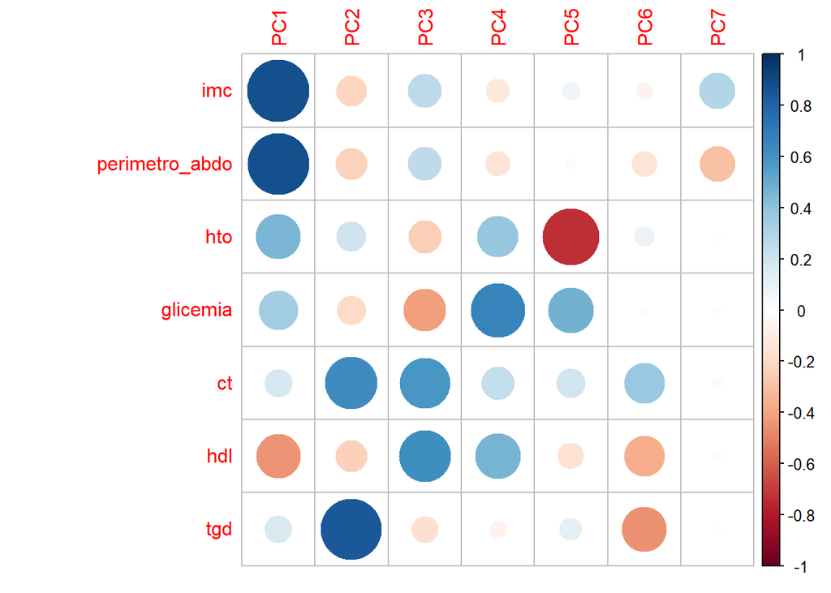

```r
corrplot(cor(cardio1,xPCA$x))
```

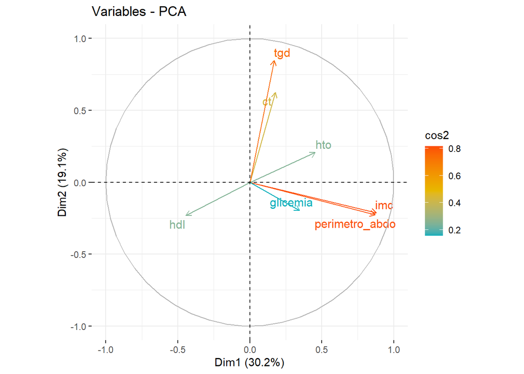

```r
## Pareciera existir correlación lineal positiva entre las variables "imc"
## y "perimetro_abdo" con la PC 1, pi-value 0,878 y 0,870 respectivamente
## pareciera existir correlación lineal positiva entre la variable "tgd"
## y la PC2, pi-value 0,8469, y el colesterol total en un nivel mucho menor (0.62).
## Entre la variable "hto" y la PC5, , pareciera existir correlación lineal negativa
## con pi-value -0,732.


fviz_pca_var(xPCA, col.var = "cos2",
             gradient.cols = c("#00AFBB", "#E7B800", "#FC4E07"),
             repel = TRUE # Avoid text overlapping
)
```

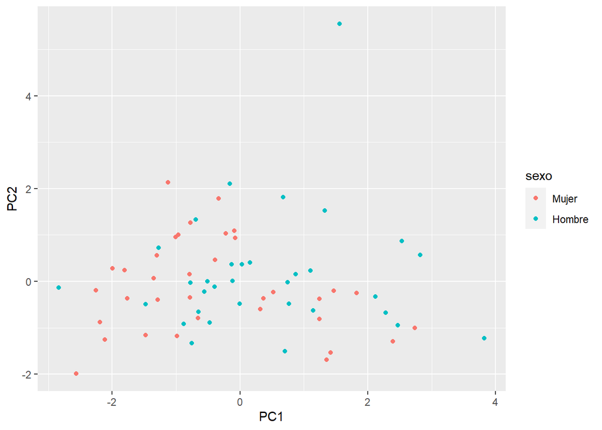

```r
## En este gráfico se verifica lo dicho anteriormente sobre las primeras dos componentes
## y su relación con las variables.

#
## Vinculación con sexo: Se genera una nueva matriz, que tenga los campos de
## la matriz original más los componentes transformados generados


rel_sexo <- cbind(cardio,xPCA$x)
ggplot(rel_sexo)+
  aes(x=PC1, y=PC2, color=sexo)+
  geom_point()
```

```r
# Mirando en el gráfico de las primeras dos componentes principales, con diferencia en color
# por sexo, no parece ser posible diferencias hombres y mujeres por valores de los datos
# transformados
```

d- Análisis Clusters - metodo jerarquico Aplicaremos clustering jerarquico, que tiene en cuenta el orden de parecido entre las observaciones a clasificar, y el agrupamiento se realiza de forma jerárquica según la similitud de las observaciones. Para esto procederemos, primero procederemos a estandarizar la matriz. Luego, a calcular la matriz de distancias utilizando el método euclideo. Para agrupar el cluster se utilizará el método de Ward, en donde en cada paso se debe encontrar el par de clusters que llevan al incremento minimo del total de la varianza del cluster después de mezclarlos. En su cálculo intervienen el vector de medias de cada grupo y la cantidad de individuos en el grupo. Se utilizaran variables cuantitativas continuas (matriz cardio1) (El método de similaridad de GoweR no fue dado en el curso)

```r
# Estandarización variables a clusterizar, con distribuciones normales de
# media 0 y desvío estandar 1.
RAstd <- scale(cardio1)

summary (RAstd)
```

```
##       imc          perimetro_abdo         hto             glicemia
##  Min.   :-1.4574   Min.   :-1.8315   Min.   :-2.9488   Min.   :-1.7490
##  1st Qu.:-0.6907   1st Qu.:-0.7678   1st Qu.:-0.6619   1st Qu.:-0.6478
##  Median :-0.2212   Median :-0.1008   Median :-0.1210   Median :-0.1878
##  Mean   : 0.0000   Mean   : 0.0000   Mean   : 0.0000   Mean   : 0.0000
##  3rd Qu.: 0.3917   3rd Qu.: 0.4401   3rd Qu.: 0.5485   3rd Qu.: 0.3838
##  Max.   : 3.2183   Max.   : 2.7839   Max.   : 2.1927   Max.   : 3.6596
##        ct               hdl                tgd
##  Min.   :-1.8589   Min.   :-2.23226   Min.   :-1.1815
##  1st Qu.:-0.7293   1st Qu.:-0.69882   1st Qu.:-0.5014
##  Median :-0.1446   Median : 0.02577   Median :-0.2988
##  Mean   : 0.0000   Mean   : 0.00000   Mean   : 0.0000
##  3rd Qu.: 0.5796   3rd Qu.: 0.53130   3rd Qu.: 0.1498
##  Max.   : 2.2076   Max.   : 2.41861   Max.   : 5.5765
```

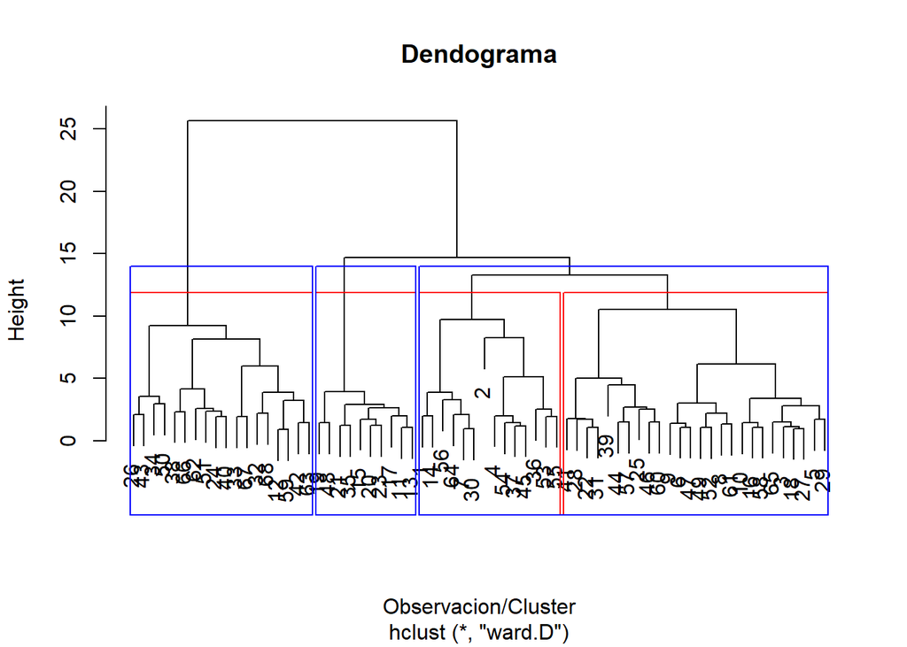

```r
#Calculo de distancias Euclideas

d   <- dist(RAstd, method = "euclidean")

# Agrupamiento con método de Ward por ser menos sensible a outliers
fit <- hclust(d, method = "ward.D")

#Dendograma

plot(fit, main="Dendograma", xlab="Observacion/Cluster")


#de la observación del dendograma pareciera lógico clusterizar
#en 3 o 4 grupos
rect.hclust(fit, k = 4, border = "red")

rect.hclust(fit, k = 3, border = "blue")
```

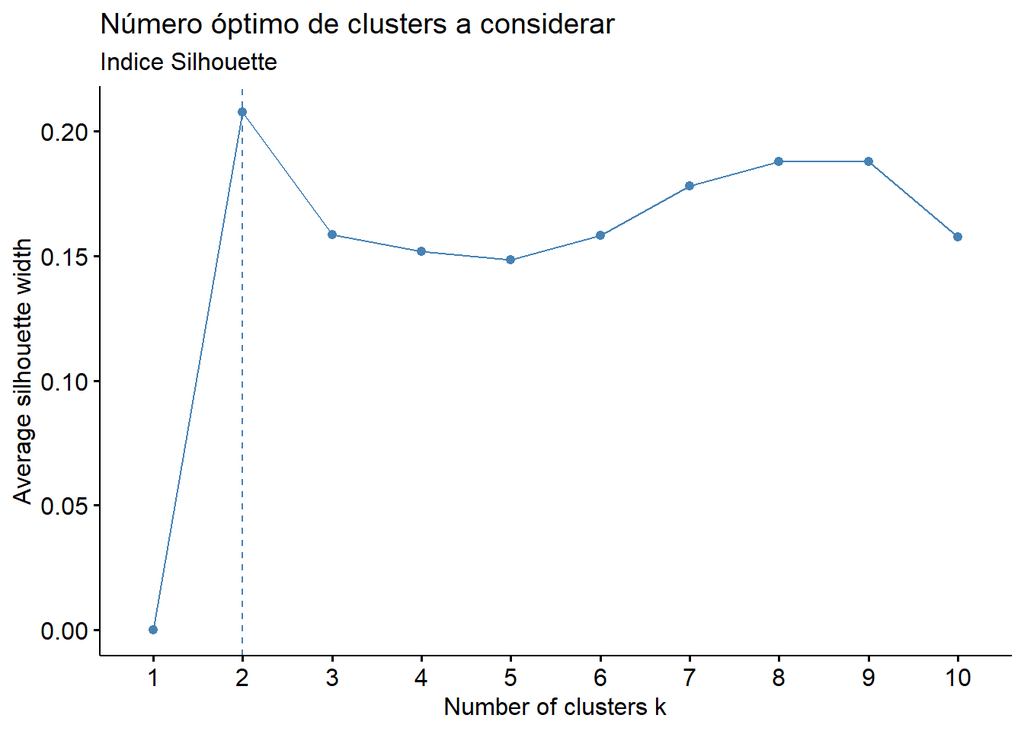

```r
# Indice Silhouette

fviz_nbclust(RAstd, kmeans, method = "silhouette") +
  labs(title    = "Número óptimo de clusters a considerar",
       subtitle = "Indice Silhouette")
```

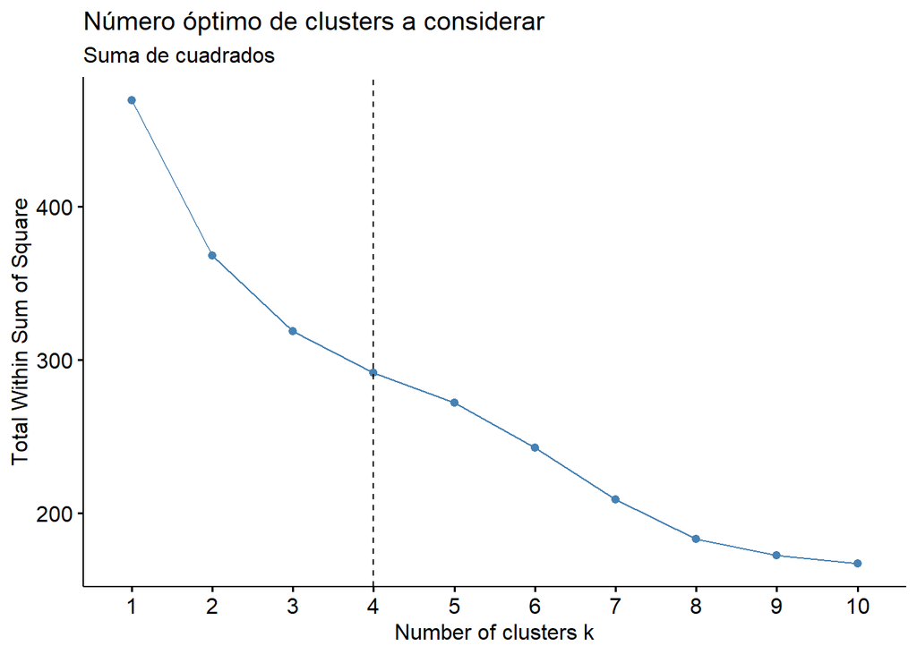

```r
fviz_nbclust(RAstd, kmeans, method = "wss") +
  labs(title    = "Número óptimo de clusters a considerar",
       subtitle = "Suma de cuadrados")+
  geom_vline(xintercept = 4, linetype = 2)
```

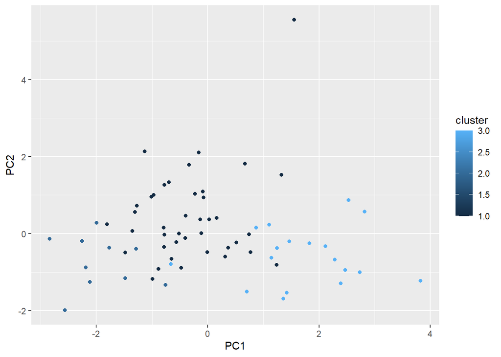

```r
## Según el indice de Silhoutte, deberíamos tomar dos clusters. Considerando la suma
## de cuadrados podríamos ver que a partor del carto cluster se deja de bajar la variabilidad.
## Podemos entonces con estos dos criterios adopar clusters de 3/4 particiones, consideraremos
## 3.

groups <- cutree(fit, k = 3)


# Unir los clusters formado con los datos originales para poder describir los grupos

RAstd         <- data.frame(RAstd)
RAstd$cluster <- groups
cardio1$cluster <-groups
cardio$cluster <- groups
rel_sexo$cluster <- groups

ggplot(rel_sexo)+
  aes(x=PC1, y=PC2, color=cluster)+
  geom_point()
```

```r
## Vemos que en el tercer cluster tienen altos valores de la PC1, lo que está relacionado con
## altos IMC y perimetro de abodemenes. El segundo clsuter, tiene altos vlores negativos
## de la PC!, con lo que podemos esperar que tengan bajos valros de IMC y perimetro abdominal.
## En el primer cluster hay cierta dispersión con respecto a la primer componente PC1, pero
## altos valores de la PC2, con lo que podemos esperar que tengan altos trigliceridos.


vars_to_cluster <- colnames(cardio1[,-8])


# Caracterizar los segmentos encontrados (utilizando las variables estandarizadas)
formula_para_describir <- as.formula(
  paste0( paste(vars_to_cluster, collapse = " + "), " ~ cluster")
)


formula_para_describir
```

```
## imc + perimetro_abdo + hto + glicemia + ct + hdl + tgd ~ cluster
```

```r
cardio <- cbind(cardio, groups)


tablaResumen <- describeBy(
  formula_para_describir,
  mat = TRUE,
  data = RAstd
)

cat("\n### Medidas resúmenes (variables estandarizadas) para los clusters elegidos.\n")
```

```
##
## ### Medidas resúmenes (variables estandarizadas) para los clusters elegidos.
```

```r
kable(
  tablaResumen %>%
    dplyr::mutate(variable = rownames(.),
                  cv       = 100 * sd / abs(mean) ) %>%
    dplyr::rename(cluster = group1) %>%
    dplyr::select(variable, cluster, n, mean, median, cv, min, max) %>%
    arrange(as.numeric(as.character(cluster))),
  digits = 2, caption = "Tabla 2. Valores de los clusters normalizados"
)
```

Tabla 2. Valores de los clusters normalizados

| variable | cluster | n | mean | median | cv | min | max |
| --- | --- | --- | --- | --- | --- | --- | --- |
| imc1 | 1 | 40 | -0.35 | -0.38 | 159.05 | -1.40 | 0.97 |
| perimetro_abdo1 | 1 | 40 | -0.33 | -0.46 | 185.78 | -1.33 | 1.20 |
| hto1 | 1 | 40 | -0.03 | -0.08 | 4100.30 | -2.95 | 2.19 |
| glicemia1 | 1 | 40 | -0.08 | -0.19 | 991.16 | -1.47 | 1.88 |
| ct1 | 1 | 40 | 0.11 | -0.08 | 864.41 | -1.65 | 2.21 |
| hdl1 | 1 | 40 | -0.25 | -0.21 | 303.55 | -2.23 | 1.47 |
| tgd1 | 1 | 40 | 0.28 | -0.11 | 421.48 | -0.89 | 5.58 |
| imc2 | 2 | 10 | -0.83 | -0.77 | 52.62 | -1.46 | -0.17 |
| perimetro_abdo2 | 2 | 10 | -0.87 | -0.86 | 71.08 | -1.83 | 0.12 |
| hto2 | 2 | 10 | -0.57 | -0.42 | 86.21 | -1.28 | -0.08 |
| glicemia2 | 2 | 10 | -0.85 | -0.80 | 54.62 | -1.75 | -0.19 |
| ct2 | 2 | 10 | -0.76 | -0.76 | 90.50 | -1.86 | 0.56 |
| hdl2 | 2 | 10 | 1.16 | 1.04 | 61.60 | 0.13 | 2.22 |
| tgd2 | 2 | 10 | -0.64 | -0.62 | 54.66 | -1.18 | -0.13 |
| imc3 | 3 | 18 | 1.23 | 1.24 | 74.48 | -0.31 | 3.22 |
| perimetro_abdo3 | 3 | 18 | 1.22 | 1.20 | 64.51 | -0.10 | 2.78 |
| hto3 | 3 | 18 | 0.38 | 0.34 | 223.60 | -0.89 | 1.72 |
| glicemia3 | 3 | 18 | 0.65 | 0.23 | 192.46 | -1.14 | 3.66 |
| ct3 | 3 | 18 | 0.17 | 0.25 | 614.31 | -1.46 | 1.78 |
| hdl3 | 3 | 18 | -0.08 | -0.31 | 1475.32 | -2.03 | 2.42 |
| tgd3 | 3 | 18 | -0.26 | -0.42 | 200.15 | -1.09 | 0.66 |

```r
## Mirando la matriz estandariza podemoes verificar que en el cluster 1 hay un alto valor
## de trigliceridos (+0.28), que en el cluster 2 los valroes de IMC y Perimetro abdimnal son bajos
## (0.83 y -0.87) y que en el cluster 3 estas variables tienen un alto valor (1.23 y 1.22)

# Caracterizar los segmentos encontrados (utilizando las variables originales)

cardio1         <- data.frame(cardio1)


tablaResumen <- describeBy(
  formula_para_describir,
  mat = TRUE,
  data = cardio1
)

cat("\n### Medidas resúmenes (variables originales) para los clusters elegidos.\n")
```

```
##
## ### Medidas resúmenes (variables originales) para los clusters elegidos.
```

```r
kable(
  tablaResumen %>%
    dplyr::mutate(variable = rownames(.),
                  cv       = 100 * sd / abs(mean) ) %>%
    dplyr::rename(cluster = group1) %>%
    dplyr::select(variable, cluster, n, mean, median, cv, min, max) %>%
    arrange(as.numeric(as.character(cluster))),
  digits = 2, caption= "Tabla 3. Valores de los diferentes clusters"
)
```

Tabla 3. Valores de los diferentes clusters

| variable | cluster | n | mean | median | cv | min | max |
| --- | --- | --- | --- | --- | --- | --- | --- |
| imc1 | 1 | 40 | 27.52 | 27.35 | 10.14 | 22.22 | 34.15 |
| perimetro_abdo1 | 1 | 40 | 95.83 | 94.00 | 8.86 | 82.00 | 117.00 |
| hto1 | 1 | 40 | 41.84 | 41.60 | 12.22 | 28.20 | 52.20 |
| glicemia1 | 1 | 40 | 0.98 | 0.96 | 14.35 | 0.73 | 1.33 |
| ct1 | 1 | 40 | 217.22 | 210.00 | 17.05 | 151.00 | 296.00 |
| hdl1 | 1 | 40 | 53.35 | 54.00 | 21.44 | 24.00 | 79.00 |
| tgd1 | 1 | 40 | 1.55 | 1.28 | 52.03 | 0.74 | 5.21 |
| imc2 | 2 | 10 | 25.07 | 25.40 | 8.81 | 21.91 | 28.40 |
| perimetro_abdo2 | 2 | 10 | 88.35 | 88.50 | 9.69 | 75.00 | 102.00 |
| hto2 | 2 | 10 | 39.29 | 40.00 | 5.87 | 36.00 | 41.60 |
| glicemia2 | 2 | 10 | 0.84 | 0.85 | 9.84 | 0.68 | 0.96 |
| ct2 | 2 | 10 | 184.40 | 184.50 | 14.01 | 143.00 | 234.00 |
| hdl2 | 2 | 10 | 74.30 | 72.50 | 14.24 | 59.00 | 90.00 |
| tgd2 | 2 | 10 | 0.92 | 0.92 | 26.20 | 0.54 | 1.27 |
| imc3 | 3 | 18 | 35.50 | 35.53 | 13.07 | 27.73 | 45.54 |
| perimetro_abdo3 | 3 | 18 | 117.25 | 117.00 | 9.27 | 99.00 | 139.00 |
| hto3 | 3 | 18 | 43.73 | 43.55 | 9.02 | 37.80 | 50.00 |
| glicemia3 | 3 | 18 | 1.11 | 1.04 | 20.08 | 0.79 | 1.65 |
| ct3 | 3 | 18 | 219.28 | 222.50 | 17.75 | 158.00 | 280.00 |
| hdl3 | 3 | 18 | 55.94 | 52.50 | 30.94 | 27.00 | 93.00 |
| tgd3 | 3 | 18 | 1.18 | 1.06 | 30.69 | 0.60 | 1.81 |

e- Construcción de arbol predictivo.

Variable de decision dicotomica

```r
cardio <- mutate(cardio, Obesidad = ifelse(cardio$imc>=30, "SI", "NO"))
cardio$Obesidad <- factor(cardio$Obesidad)
colnames(cardio)
```

```
##  [1] "id"             "sexo"           "imc"            "perimetro_abdo"
##  [5] "hto"            "glicemia"       "ct"             "hdl"
##  [9] "tgd"            "cluster"        "groups"         "Obesidad"
```

```r
formula <- formula(
  Obesidad ~ sexo +  hto + glicemia + ct + hdl + tgd)

set.seed(123)

## Se usará en principio el método CART sin el kfold, a que el tamaño
## de la muestra parece ser pequeño para armar grupos y ademas no hay en la muestra
## ningún dato faltante que se haya tenido que inventar. Luego se usa un arbol con validación
## cruzada para comparar y arroja el mismo resultado


arbol.train <- rpart(formula, data = cardio)
arbol.train
```

[output not shown]

```
## n= 68
##
## node), split, n, loss, yval, (yprob)
##       * denotes terminal node
##
## 1) root 68 25 NO (0.6323529 0.3676471)
##   2) hto< 40.5 24  3 NO (0.8750000 0.1250000) *
##   3) hto>=40.5 44 22 NO (0.5000000 0.5000000)
##     6) glicemia< 0.94 17  4 NO (0.7647059 0.2352941) *
##     7) glicemia>=0.94 27  9 SI (0.3333333 0.6666667) *
```

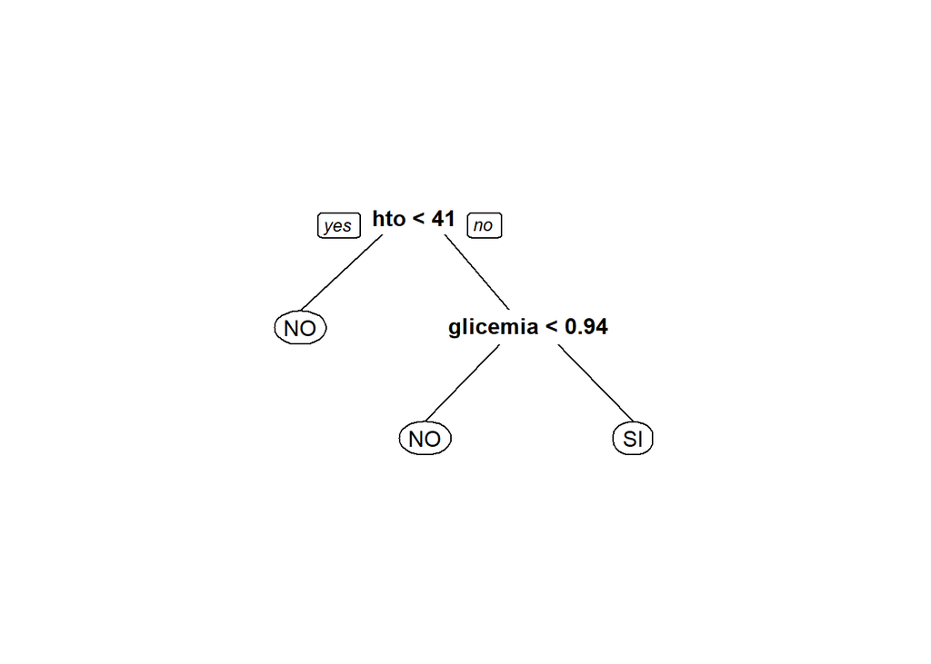

```r
prp(arbol.train)
```

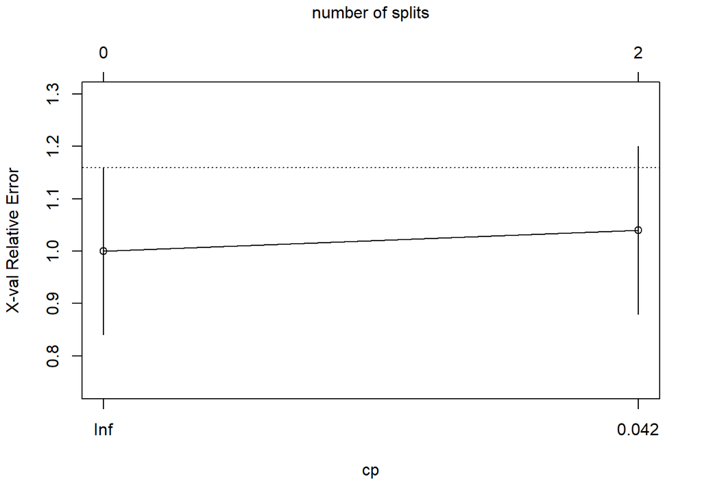

```r
plotcp(arbol.train, upper = "splits")
```

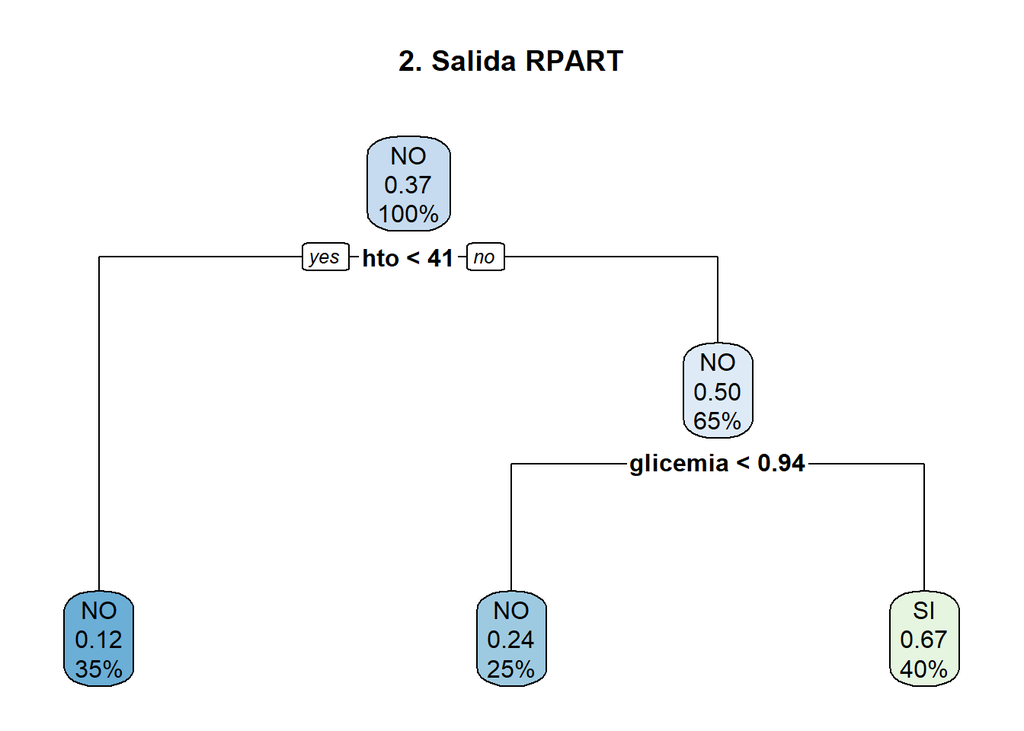

```r
rpart.plot(arbol.train, main = "2. Salida RPART")
```